# Advanced Topics in Data Science 2018/2019: Practical Assignment - Movies Recommendation

[Furthurmore, in comparison to figure 18, it is possible to register a slight decrease of precision values but an increase of recall values. For data in binary form, the Romance genre show a positive effect on the UBCF model.]

Next, we check the influence of Romance genre in non-binary data. Since on our previously analysis the IBCF exhibited the best results when predicting movies ratings, the standard and k10 parameters were selected.

1.*Standard IBCF:* according to the recommender package registry, the IBCF parameters as default are Cosine similarity method, nearest neighbors (k) as 30, the similarity matrix normalization is set as center, and alpha is set as 0.5. 2.*k 10 IBCF:* here the k was set as 10, one third of the default value.

As we can see in figure 32 and in comparison with figure 21, the values of error, in general, are similar, not indicating any influence of the Romance genre in the model. To validate these results, a manual evaluation was performed.

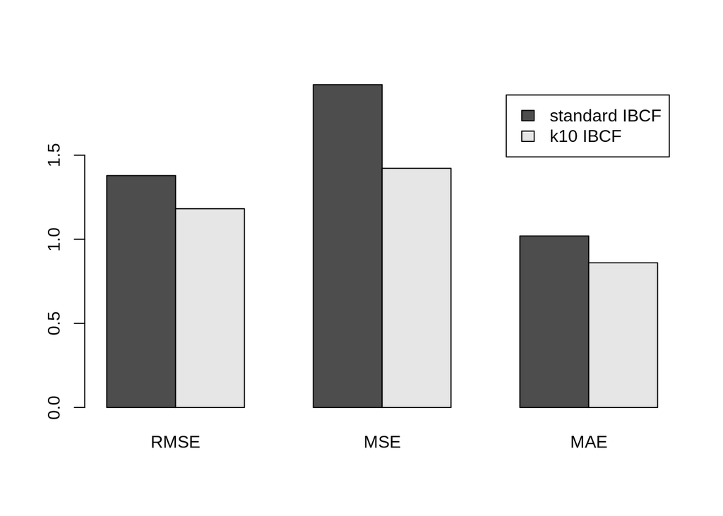

Figure 32: RMSE, MSE and MAE errors results for the evaluation of IBCF models under two different sets of parameters, for top 1,2 and 5 recommendation

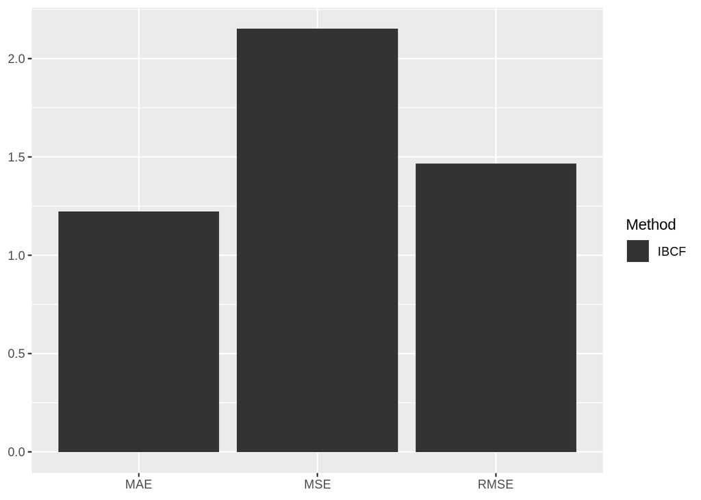

Figure 33: RMSE, MSE and MAE errors results for the evaluation of IBCF method under their best performing set of parameters.

The results obtained are in agreement to the ones obtained initially, presenting however slightly higher error values.

[Furthermore, in comparison to figure 24, the error values present in graphic 33 are bigger indicating that taking into account the Romance genre, IBCF becomes a less reliable model]

Thereafter the top-n critic was analyzed in the non-binary data. The Popular model was the best one before, so we tested in this context.

For POP method, two different sets of parameters were tested:

Figure 34 shows a slight increase in precision values when comparing to figure 27, but in general the context did not affect the results. To validate these results, a manual evaluation was performed.

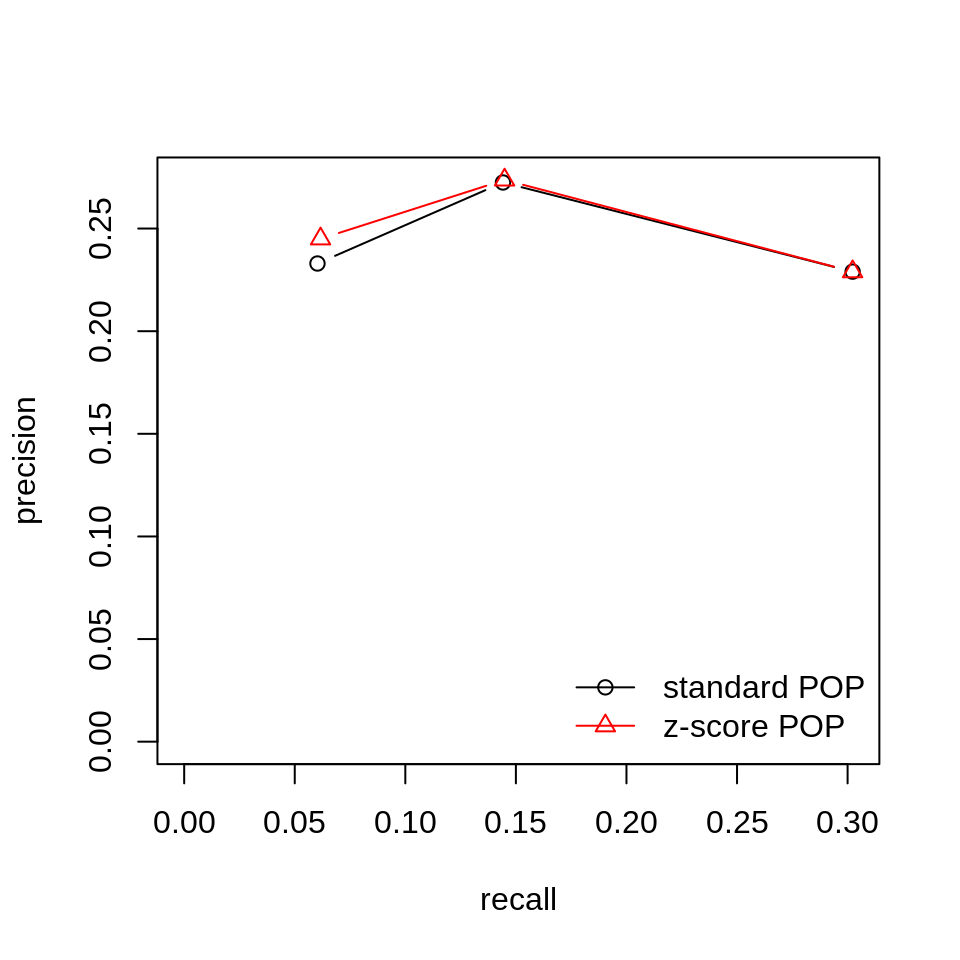

Figure 34: Precision and recall results for the evaluation of Popular models under two different sets of parameters, for top 1,2 and 5 recommendation

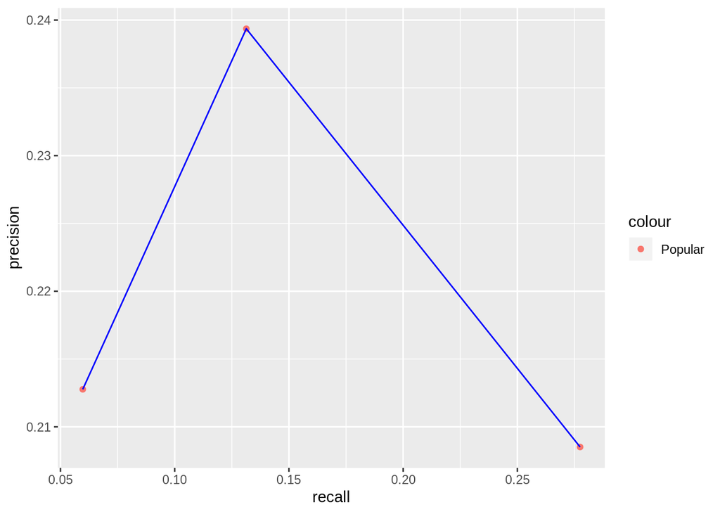

Figure 35: Precision and recall results for the evaluation of Popular method under his best performing set of parameters for top 1,2 and 5 recommendation.

The results are in agreement to the ones obtained initially. However, as we can see in figure 34, the quality prediction for the top 5 recommendation decreased significantly.

[By the comparison of figures 29 and 35, it is possible to see a totally different result in the two graphics. The graphic above has the worst results than figure 29, indicating that genre has a negative effect on the Popular model.]

## Movie Run-time

The analysis of figure 7 shows that movies with run time over 120 minutes tend to present higher scores, so we select a subset comprising only these movies.

For UBCF method, two different sets of parameters were tested:

1. *Cosine UBCF:* here we changed the similarity method from jaccard to cosine.
2. *nn 50 UBCF:* here the nn was set as 50, twice the default value.

Results on figure 36 show that nn50 protocol has a better performance than cosine protocol in UBCF model. Through this graph it is possible to verify similar results when compare with the data obtained in figure 14. These results indicates a neutral effect of movies run time in the model.

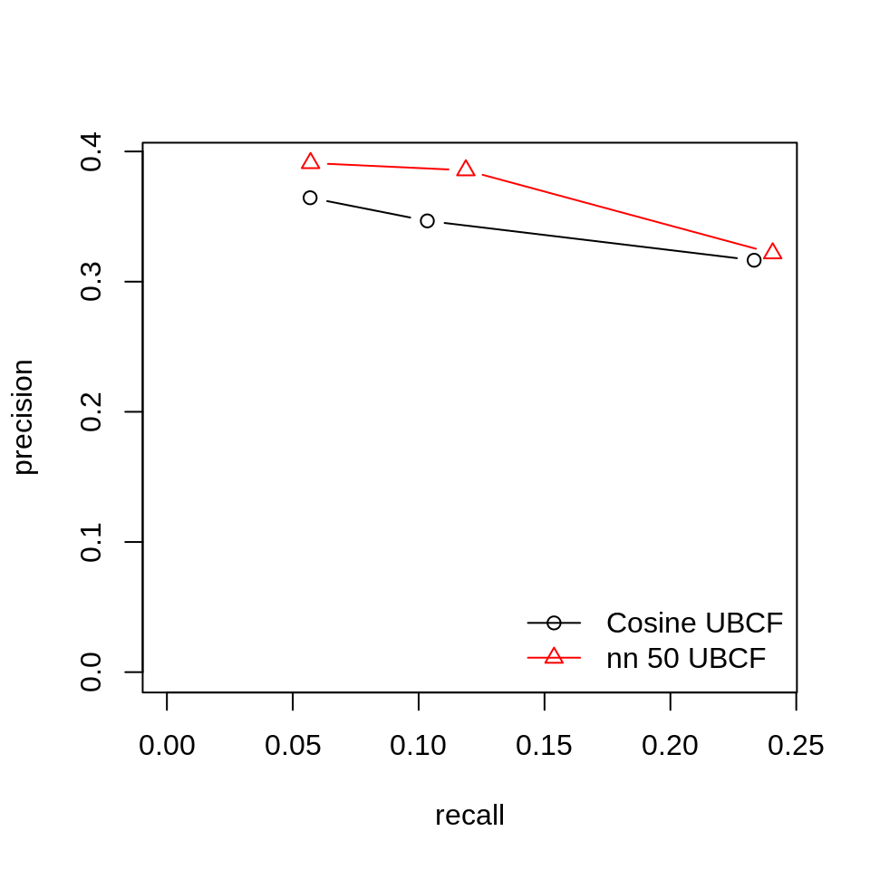

Figure 36: Precision and recall results for the UBCF model under two different sets of parameters

In order to validate the results obtained above, manual evaluation was also performed.

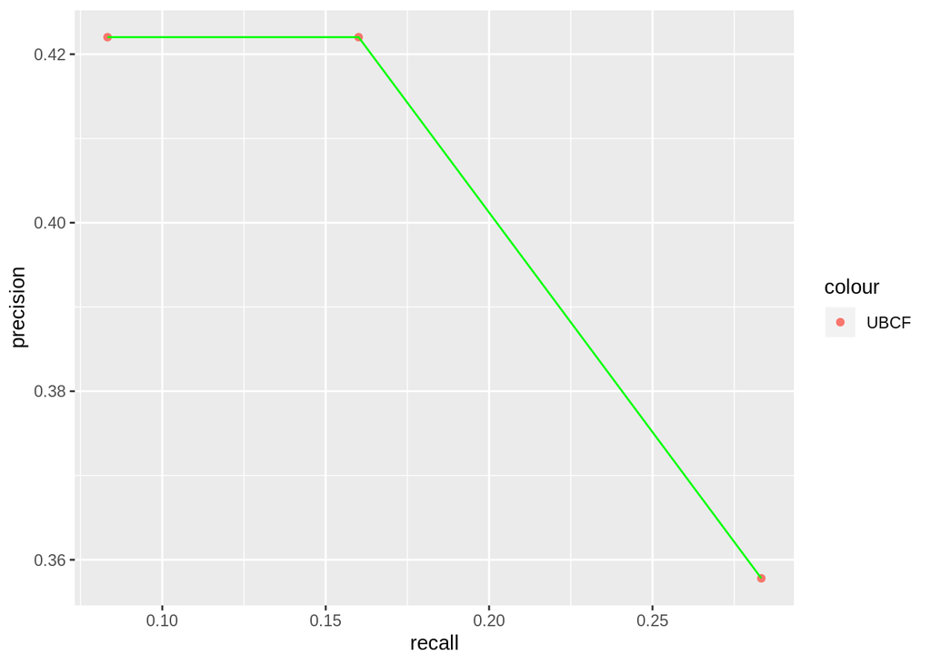

Figure 37: Precision and recall results for the evaluation of UBCF model

Overall, the results are in agreement to the ones obtained initially. However, as we can see in figure 37, the quality prediction for the top 5 recommendation decreased significantly.

[The results in figure 37 show a decrease in precision values when comparing to figure 18. Although the recall presents an increase comparing to figure 18.]

Next, we check the influence of run time considering non-binary data. Since IBCF was the best model, the standard and k10 parameters were selected.

1.*Standard IBCF:* according to the recommender package registry, the IBCF parameters as default are Cosine similarity method, nearest neighbors (k) as 30, the similarity matrix normalization is set as center, and alpha is set as 0.5. 2.*k 10 IBCF:* here the k was set as 10, one third of the default value.

As we can see in figure 38 and in comparison with figure 21, the values of error are, in general, similar, not indicating any influence by the run time of the films over the model.

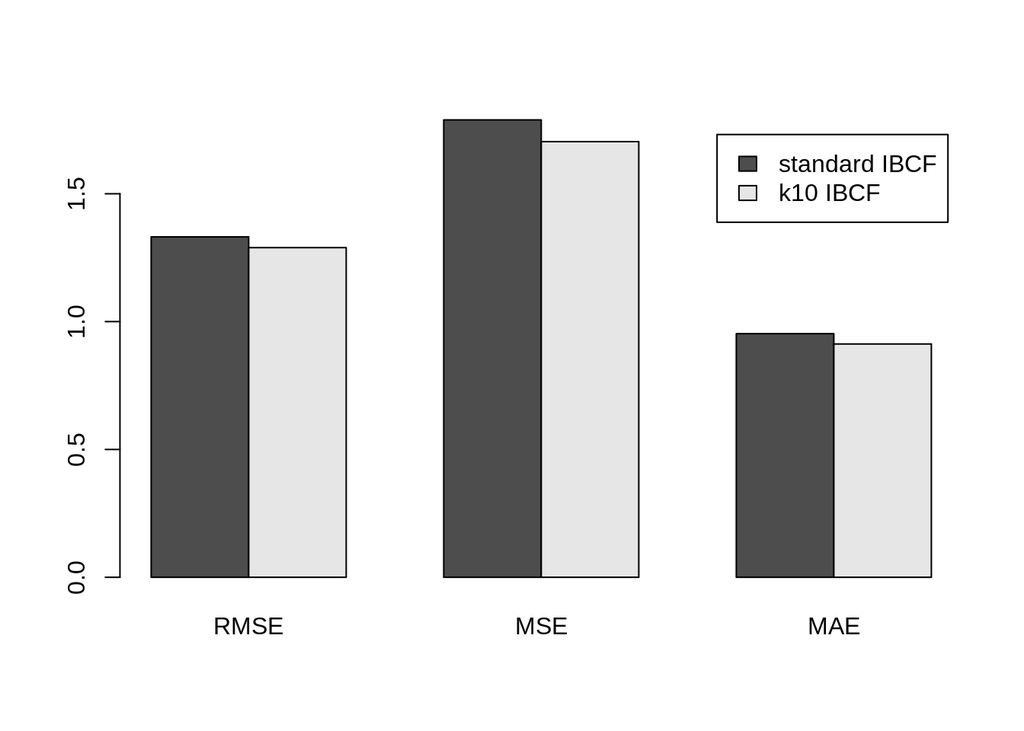

Figure 38: RMSE, MSE and MAE errors results for the evaluation of IBCF models under two different sets of parameters, for top 1,2 and 5 recommendation

To validate these results, a manual evaluation was performed.

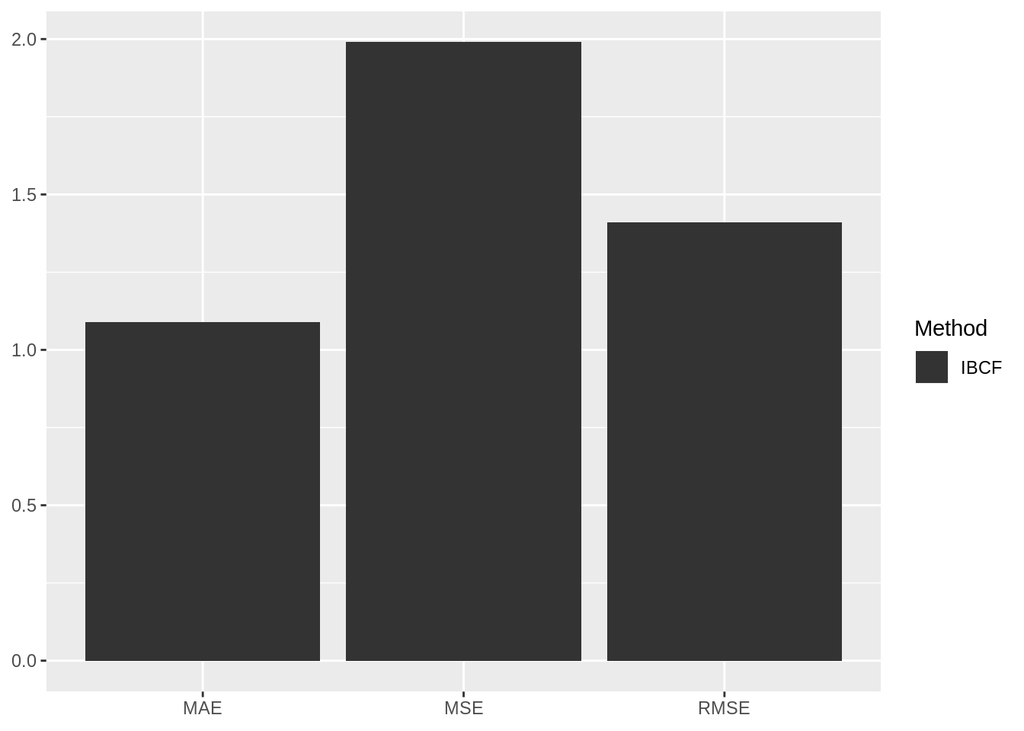

Overall, the results present on figure 39 are in agreement to the ones obtained initially, presenting only slight differences on the errors values in relation to figure 38.

Thereafter the top-n critic was analyzed considering non-binary data. The Popular model was the best one before so it was tested again when performing context aware analysis.

For POP method, two different sets of parameters were tested:

Figure 40 shows that precision and recall values are very similar to the ones obtained in figure 27. Hence, in general, the context did not affect the results. To validate these results, a manual evaluation was performed.

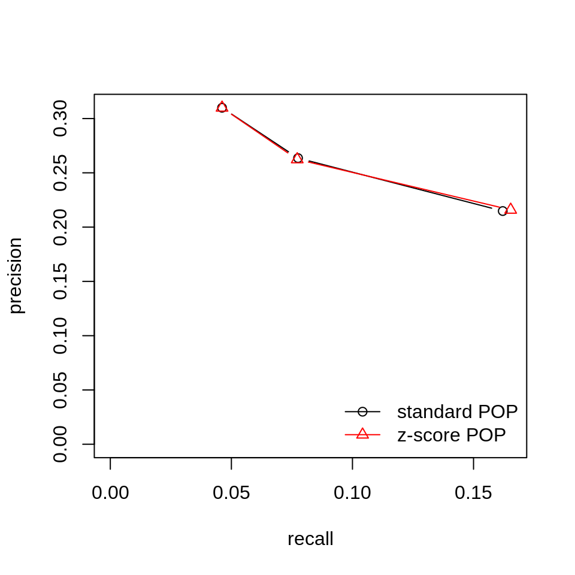

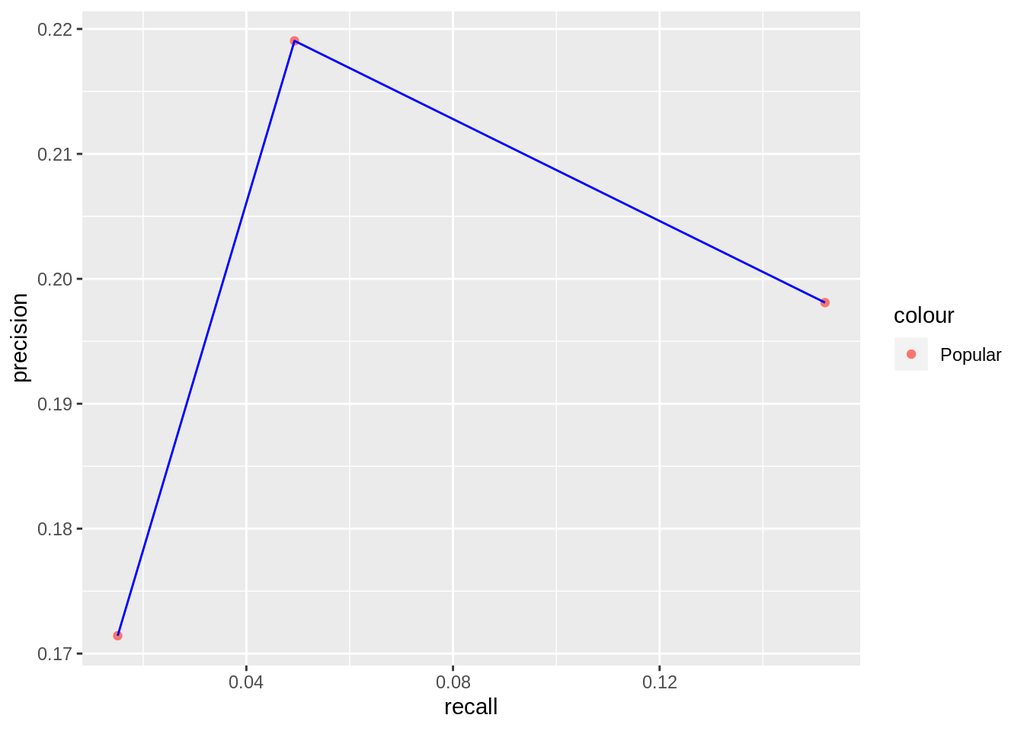

Figure 40: Precision and recall results for the evaluation of Popular method under his best performing set of parameters for top 1,2 and 5 recommendation.

## Movie Rating (G,NR,PG,PG-13,R)

Through the analysis of figure 6 we selected the Parent-guide type of movies due to the mean rating presented.

For UBCF method, two different sets of parameters were tested:

1. *Cosine UBCF:* here we changed the similarity method from jaccard to cosine.
2. *nn 50 UBCF:* here the nn was set as 50, twice the default value.

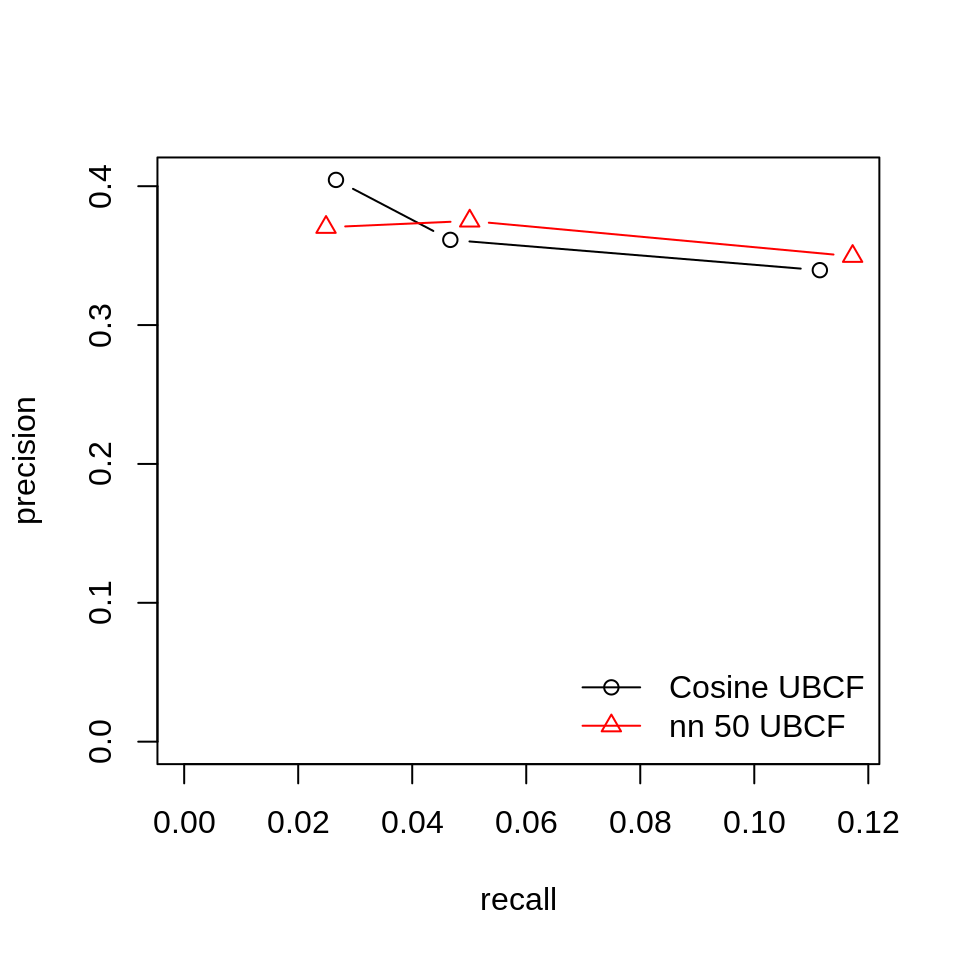

Figure 41: Precision and recall results for the UBCF model under two different sets of parameters

In order to validate the results obtained above, manual evaluation was also performed.

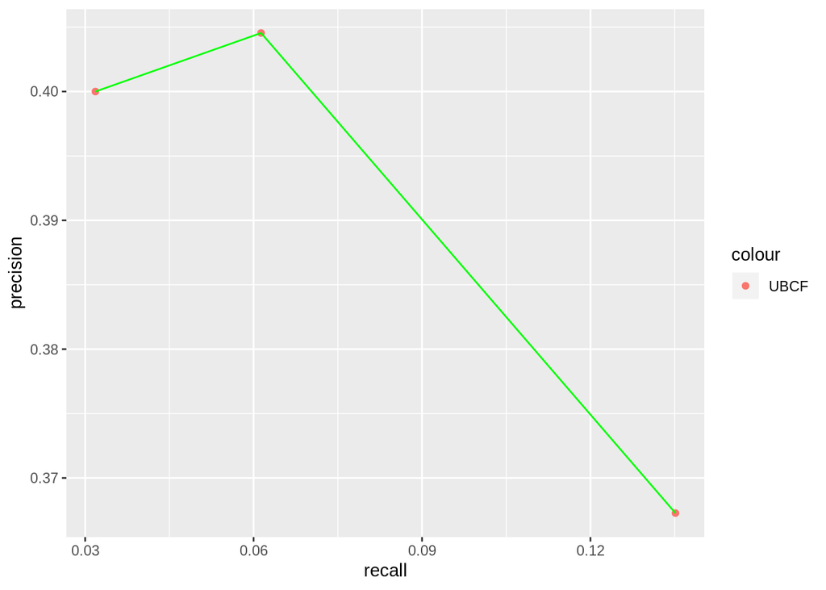

Figure 42: Precision and recall results for the evaluation of UBCF model

Next, we check the influence of the type of movie considering non-binary data. Since IBCF was the best model, the standard and k10 parameters were selected.

1.*Standard IBCF:* according to the recommender package registry, the IBCF parameters as default are Cosine similarity method, nearest neighbors (k) as 30, the similarity matrix normalization is set as center, and alpha is set as 0.5. 2.*k 10 IBCF:* here the k was set as 10, one third of the default value.

As we can see in figure 44 and in comparison with figure 21, the values of error are, in general, similar, not indicating any influence of the type of movie in the model.

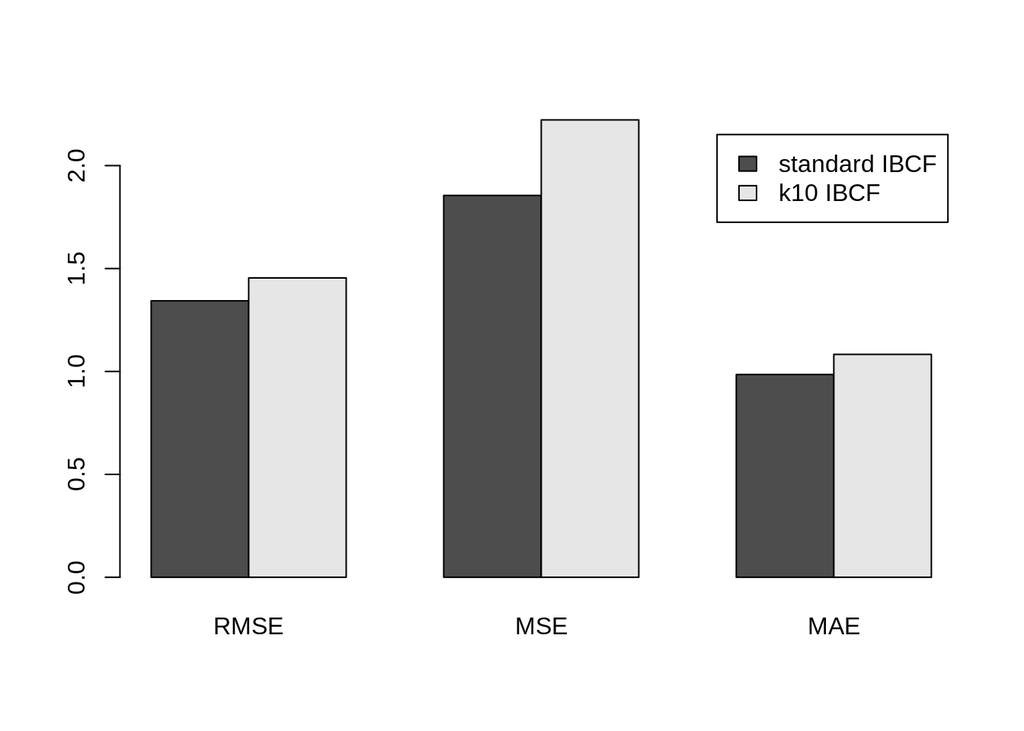

Figure 43: RMSE, MSE and MAE errors results for the evaluation of IBCF models under two different sets of parameters, for top 1,2 and 5 recommendation

To validate these results, a manual evaluation was performed.

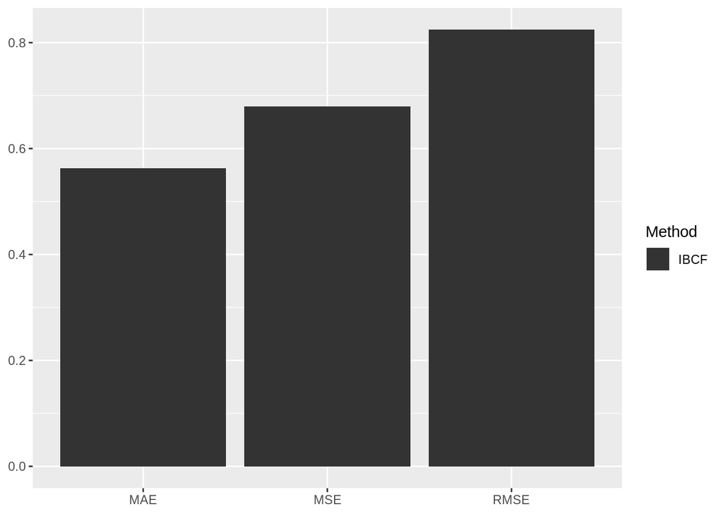

Thereafter the top-n critic was analyzed considering non-binary data. The Popular model was the best one before and hence it was tested in this context.

For POP method, unlike for the binary setup, two different sets of parameters were tested:

The results showed on figure 46 are identical to the ones obtained on figure 27, exhibiting however slightly higher recall values. Thus, in general, the context did not affect the results. To validate these results, a manual evaluation was performed.

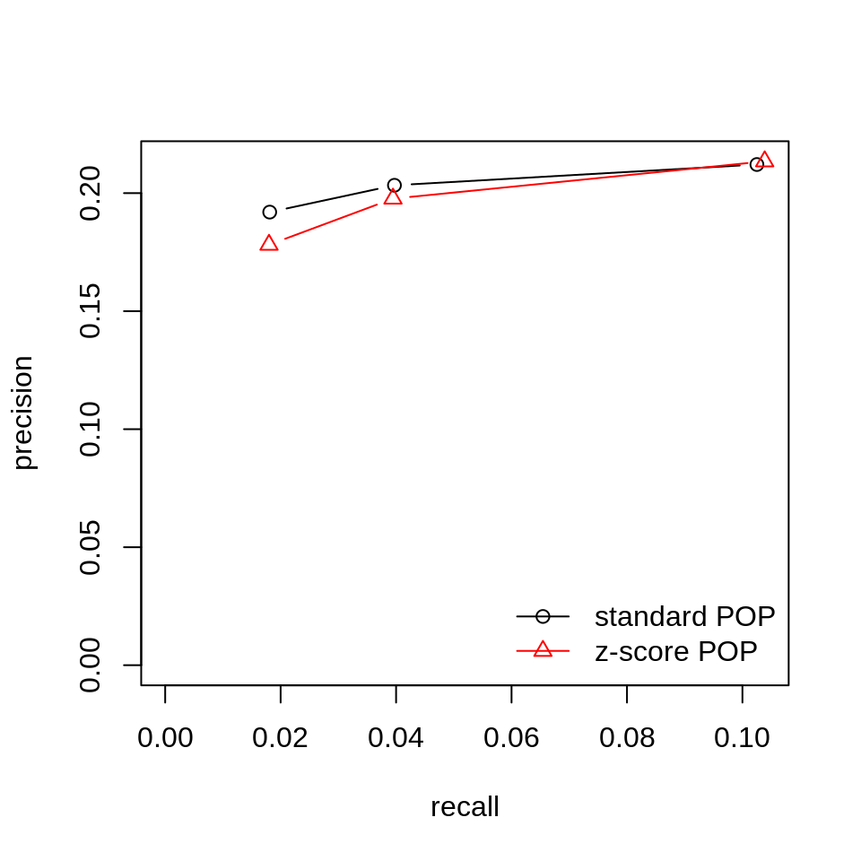

Figure 45: Precision and recall results for the evaluation of Popular models under two different sets of parameters, for top 1,2 and 5 recommendation

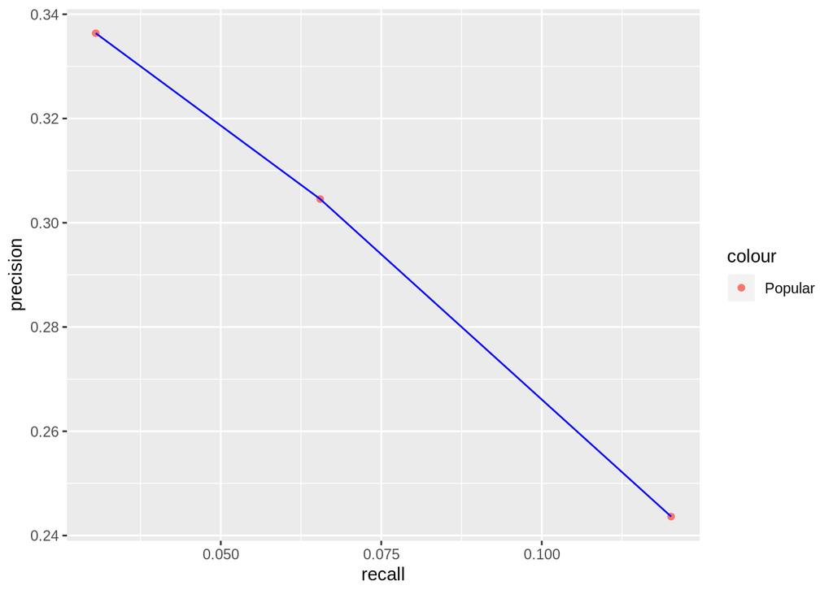

Figure 46: Precision and recall results for the evaluation of Popular method under his best performing set of parameters for top 1,2 and 5 recommendation.

## Reviews Date

Finally, the analysis of figure 2 reveals that the majority of the films reviewed are from 2010 until the present. Hence, to infer the influence of review date on the model’s quality, and attending that we were not able to develop the models considering date distribution, we selected the most recent movies reviews since 2010.

For UBCF method, two different sets of parameters were tested:

1. *Cosine UBCF:* here we changed the similarity method from jaccard to cosine.
2. *nn 50 UBCF:* here the nn was set as 50, twice the default value.

Results on figure 48 show that cosine protocol has a better performance than nn50 protocol in UBCF model. Furthermore, we verified that the results obtained are slightly lower when compare to the ones obtained previously (figure 14), even thought we do not find the differences significant. Thus, these results indicate a neutral effect of reviews date over the model prediction accuracy.

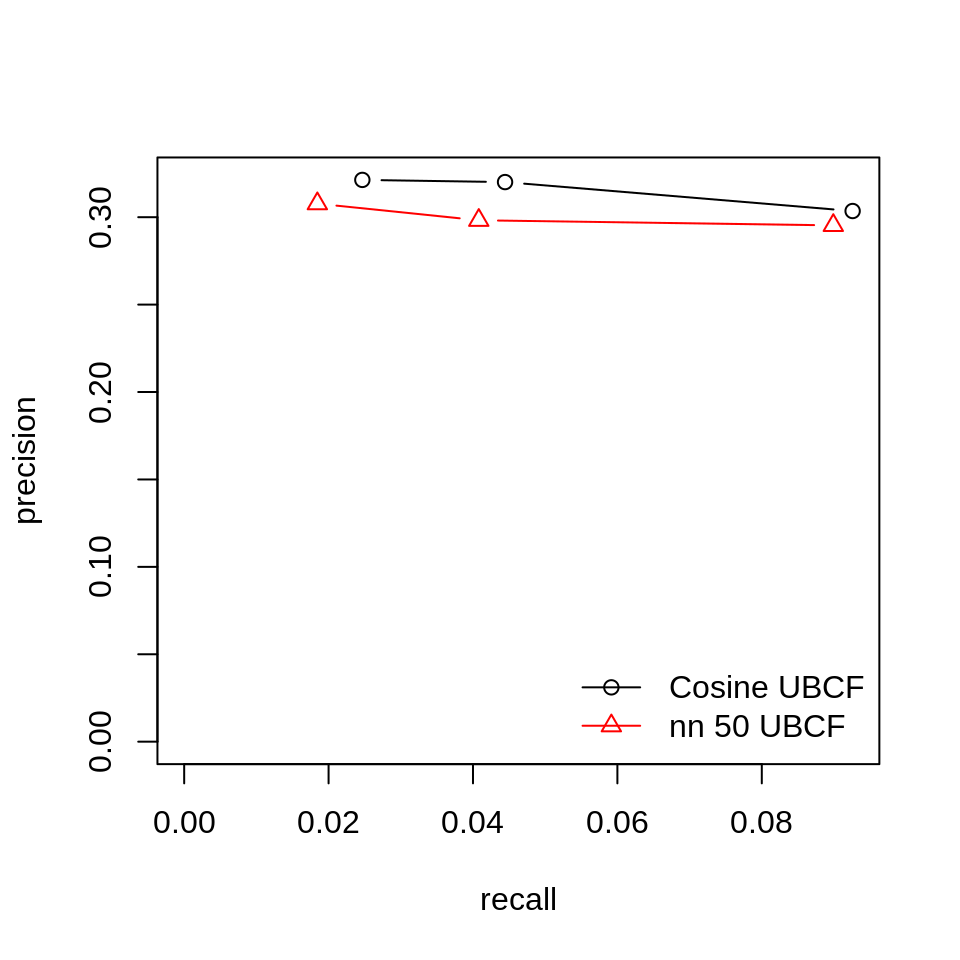

Figure 47: Precision and recall results for the UBCF model under two different sets of parameters

In order to validate the results obtained above, manual evaluation was also performed.

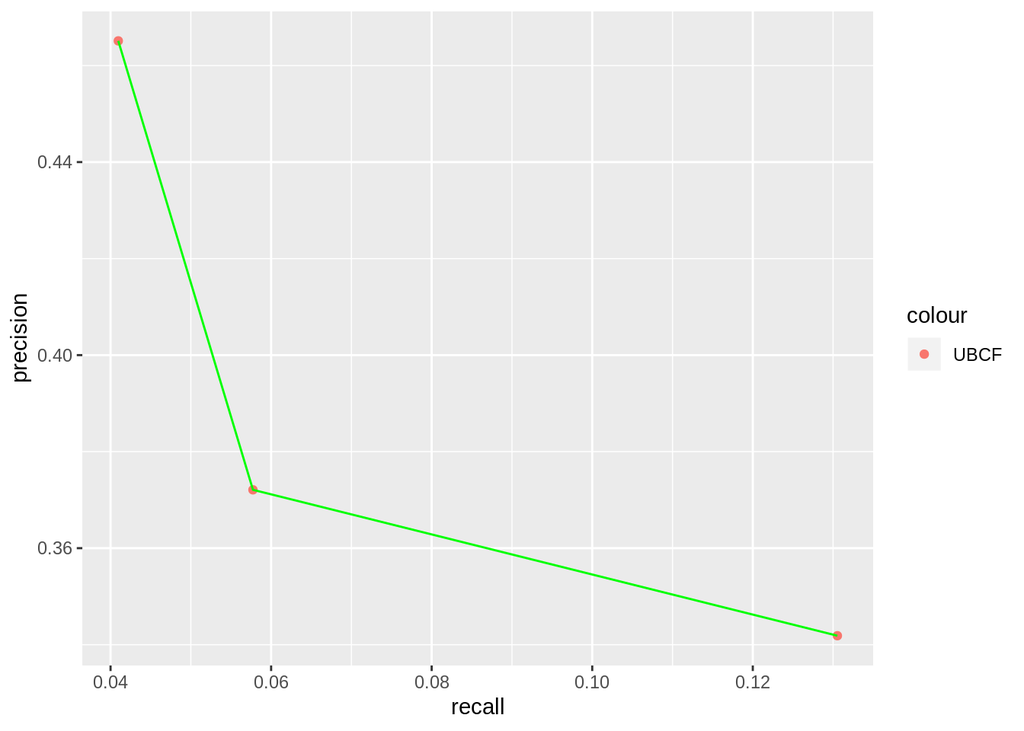

Figure 48: Precision and recall results for the evaluation of UBCF model

Next, we check the influence of the reviews date in the model’s quality considering non-binary data. Since on our previously analysis the IBCF exhibited the best results when predicting movies ratings, the standard and k10 parameters were selected.

1.*Standard IBCF:* according to the recommender package registry, the IBCF parameters as default are Cosine similarity method, nearest neighbors (k) as 30, the similarity matrix normalization is set as center, and alpha is set as 0.5. 2.*k 10 IBCF:* here the k was set as 10, one third of the default value.

As we can see in figure 50 and in comparison with figure 21, the values of error are, in general, similar, not indicating any influence reviews date over the model.

[figure not shown]

Figure 49: RMSE, MSE and MAE errors results for the evaluation of IBCF models under two different sets of parameters, for top 1,2 and 5 recommendation

To validate these results, a manual evaluation was performed.

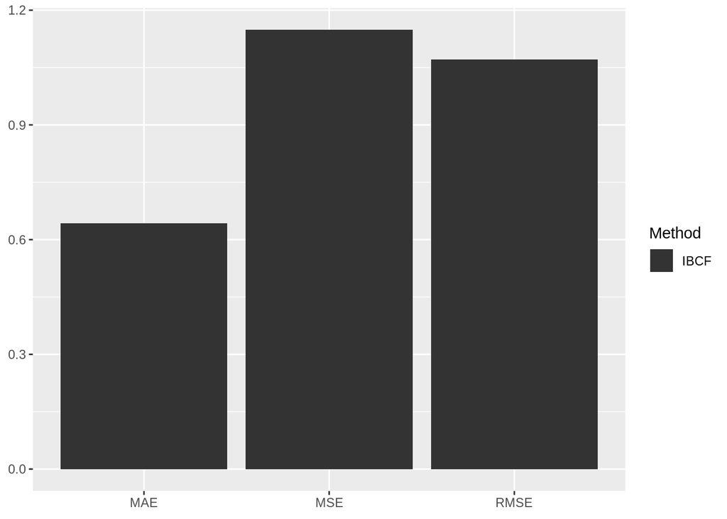

Thereafter the top-n recommendations were analyzed considering non-binary data. The Popular model was the best one before it was tested in this context.

For POP method two different sets of parameters were tested:

Results on figure 52 exhibit slightly higher precision and recall values in comparison to the ones observe on figure 27, indicating a positive effect of the reviews date in the model. However, we are not sure if this differences are enough to be considered significant. To validate these results, a manual evaluation was performed.

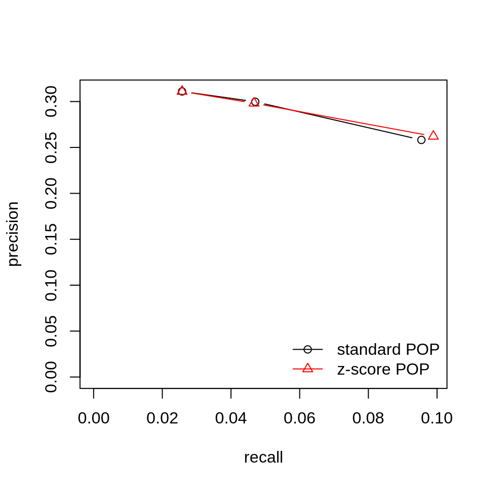

Figure 51: Precision and recall results for the evaluation of Popular models under two different sets of parameters, for top 1,2 and 5 recommendation

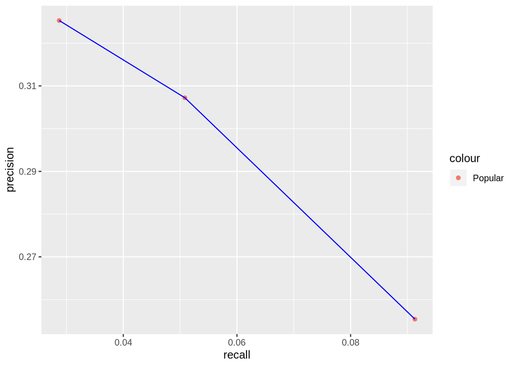

Figure 52: Precision and recall results for the evaluation of Popular method under his best performing set of parameters for top 1,2 and 5 recommendation.

# Conclusions, shortcomings and future work

In general, we believe we performed all the tasks required to successfully complete the assignment.

For binary data, our results show that the UBCF method is the one that performs better recommendations based on precision and recall evaluation (figure 17 and 18). Particularly on this analysis, we choose to select the model that exhibited a more balanced compromise between the two measures, attending that AR model also presented good results yet more unbalanced.

When considering non-binary data, two options were accessed: the prediction of movies ratings or the top-n movies recommendation. For the first approach, IBCF exhibited the best performance (figure 23 and 24). However, for top-n movies recommendation, POP model was the one that showed best results attending that, once more, we prioritized the compromise between precision and recall (figure 28 and 29). We could not find an explanation for these different results although curiously we noticed that the performance of POP model is the same for the both approaches, only the performance of UBCF and IBCF significantly decreased when making movies recommendations.

Since UBCF exhibited the best results for binary data, and attending to the already existing knowledge, we were expecting to obtain similar results for non-binary data. However, for some reason, the introduction of rating information lead to a decrease of the models performance. A reasonable explanation for this phenomenon is the possibility of the ratings submitted by the critics to be biased, not being able to express an accurate relation among movies and hence providing wrong recommendations. However, not final conclusions can be made over this subject.

Overall, in contrast to what we were expecting, the context aware analysis did not exhibited significant different results in comparison to the analysis performed initially. However, we encounter some problems while manually validating the obtained results using **Recommender** and **predict** functions. In fact, in almost all examples, we observed a significant disagreement between both results, specially when considering top-2 and top-5 recommendations. We can not infer for sure the cause for this inconsistent results. However, a possible explanation is the reduced dimension of the data sets used, attending that for each analysis a specific context was being considered, what consequently leads to a reduction of entries. In fact, the lack of improvement when taking into account specific context may be in part due to the insufficiency of the available data to make good quality recommendations.

In general, the major bottleneck encountered was to perform parameter tuning of the different approaches that ensured all models were fully and correctly functioning, and, simultaneously, enabled their distinction. In fact, as seen in many graphical representations of the results, selection of the models is not always obvious and the occurrence of many overlaps can be observed. Furthermore, there are some modeling inconsistencies that we were not able to explain such as: I) the great differences between binary and non-binary data results; II) the different results when validating our initial conclusions through **calcPredictionAccuracy**, namely for IBCF modeling when using non-binary data (figure 28 and 29) and in context aware analysis; III) the different results obtained when performing ratings prediction or movies recommendation using non-binary data (figures 23 and 24, 28 and 29, respectively).

Moreover, we were not able to take the reviews date in consideration for the model’s development, what should be accomplished in future works. Instead, as compensation, we considered only the most recent reviews when constructing context aware recommendations to access the dates influence on recommendations quality, if any. Furthermore, we believe a text mining analysis of the reviews description would provide valuable information for recommendations acquisition.

In relation to execution time, we did not found any constraints when running any of the models. Among all, only AR models were slightly slower than the remaining, as expected, although we do not find the differences significant neither enough cause to discard the models.

# References

1. Salehan, M., Mousavizadeh, M., & Koohikamali, M. (2015). A Recommender System for Online Consumer Reviews.
2. Khan, S. A., Liang, Y., & Shahzad, S. (2015). An empirical study of perceived factors affecting customer satisfaction to re-purchase intention in online stores in China. Journal of Service Science and Management, 8(03), 291.
3. Beineke, P., Hastie, T., Manning, C., & Vaithyanathan, S. (2004). Exploring sentiment summarization. In Proceedings of the AAAI spring symposium on exploring attitude and affect in text: theories and applications (Vol. 39). Palo Alto, CA: The AAAI Press.
4. Gorakala, S. K., & Usuelli, M. (2015). Building a recommendation system with R. Packt Publishing Ltd.